# Diamond Price Predictor

March 24, 2018

## Diamond Price Predictor

**Predict the price of your next diamond!** Are you having trouble deciding on how much you should spend on a diamond?

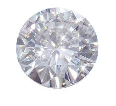

Look no further and head over to the Diamond Price Predictor: https://marcodulog.shinyapps.io/DiamondPricePredictor/

## Harness the Power of Data Science

Diamond prices can vary quite a bit but with this application, you can harness the power of data science to help you make sure that you pay the right price. We selected a sample of 5000 diamonds to help build a simple model to help you with your selection process.

## Here's a Sample of our Diamond Database

```
## # A tibble: 5,000 x 5
##    carat   cut color clarity price
##    <dbl> <ord> <ord>   <ord> <int>
##  1  1.23 Ideal     H     VS2  7130
##  2  0.30 Ideal     E     SI1   499
##  3  0.90  Good     H     VS2  3989
##  4  0.31 Ideal     G    VVS1   977
##  5  0.31 Ideal     G     VS2   652
##  6  1.01 Ideal     F      I1  3439
##  7  0.50  Fair     E     SI1  1098
##  8  0.34 Ideal     H     VS1   765
##  9  0.92 Ideal     D     SI2  5051
## 10  1.01  Good     E     SI1  5627
## # ... with 4,990 more rows
```

## Looking at all the Facets

Investigating by hand can take a while to process. Why look at complicated charts when you can point and click your way through making the right decision?

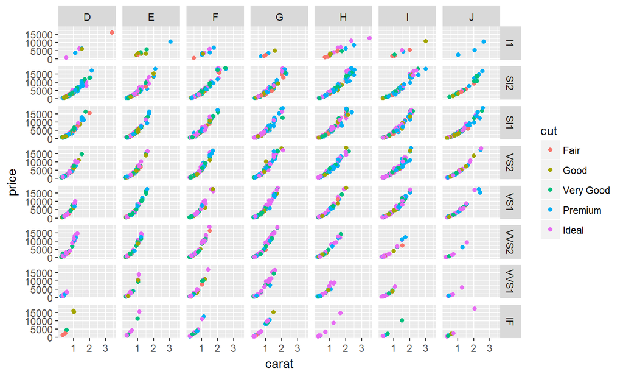